# 8.0. Regression : Introduction

The term regression was first used as a statistical concept in 1877 by Sir Francis Galton in his study that showed the height of children born to tall parents tends to move back,or "regress," toward the mean height of the population.

He designated the word *regression* as the name of the general process of predicting one variable (the height of the children) from another (the height of the parent). Later, statisticians coined the term multiple regression to describe the process by which several variables are used to predict another.

**Regression** refers to the statistical technique of modeling the relationship between variables. In this section on Simple Linear Regression, we model the relationship between two variables: a dependent variable, denoted by $Y$, and an independent variable, denoted by $X$.

- **Dependent variable** is the variable we wish to predict or explain whereas,
- **Independent variable** is the variable used to predict or explain the dependent variable.

The model we use is a straight-line relationship between X and Y.

When we model the relationship between the dependent variableY and a set of several independent variables, or when the assumed relationship between $Y$ and $X$ is curved and requires the use of more terms in the model, we use a technique called multiple regression.

Below figure is a general example of Simple Linear Regression: fitting a straight line to describe the relationship between two variables $X$ and $Y$. The points on the graph are observations of the two variables $X$ and $Y$, and the straight line describes the general movement in the data—an increase in $Y$ corresponding to an increase in $X$. An inverse straight-line relationship is also possible, consisting of a general decrease in $Y$ as $X$ increases (in such cases, the slope of the line is negative).

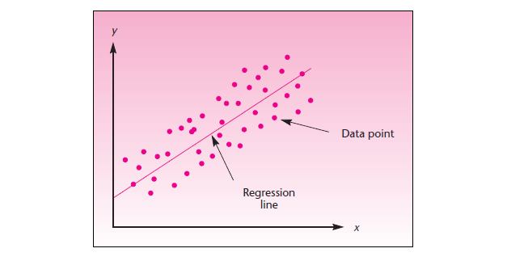

**Regression analysis is one of the most important and widely used statistical techniques and has many applications in business and economics.**

A firm may be interested in estimating the relationship between advertising and sales. The data pairs, values of $X$ paired with corresponding values of $Y$, are the points forming scatter plot as we all know. In addition to the scatter plot, the figure shows the straight line believed to best show how the general trend of increasing sales corresponds, in this example, to increasing advertising expenditures.

The relationship between advertising and sales may be well approximated by a straight line. The $X$ variable in above figure could denote advertising expenditure, and the $Y$ variable could stand for the resulting sales for the same period. The data points in this case would be pairs of observations of the form $x_1 = \$ 75,570$, $y_1 = 134,679$ units; $x_2 = \$ 83,090$, $y_2 = 151,664$ units; etc.

That is, the first month the firm spent \$ 75,570 on advertising, and sales for the month were 134,679 units; the second month the company spent \\$83,090 on advertising, with resulting sales of 151,664 units for that month; and so on for the entire set of available data.

# 8.1. Modelling

A statistical model is a set of mathematical formulas and assumptions that describe a real-world situation. We would like our model to explain as much as possible about the process underlying our data. However, due to the uncertainty inherent in all real-world situations, our model will probably not explain everything, and we will always have some remaining errors. The errors are due to unknown outside factors that affect the process generating our data.

The model captures the systematic behavior of the data, leaving out the factors that are nonsystematic and cannot be foreseen or predicted—the errors. The idea of a good statistical model is illustrated in the figure below.

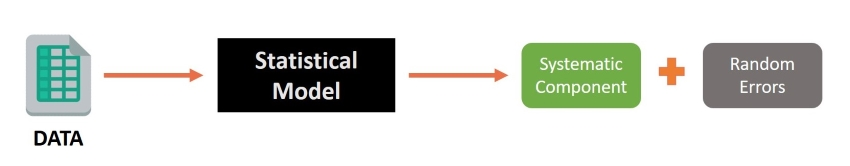

The errors, denoted by $\epsilon$, constitute the random component in the model. Since our model, we hope, captures everything systematic in the data, the remaining random errors are probably due to a large number of minor factors that we cannot trace. We assume that the random errors $\epsilon$ are normally distributed. If we have a properly constructed model, the resulting observed errors will have an average of zero and they should also be independent of one another.

First, we propose a particular model to describe a given situation. For example, we may propose a simple linear regression model for describing the relationship between two variables. Then we estimate the model parameters from the random sample of data we have. The next step is to consider the observed errors resulting from the fit of the model to the data. These observed errors, called residuals, represent the information in the data not explained by the model.

If the residuals are found to contain some non-random, systematic component, we reevaluate our proposed model and, if possible, adjust it to incorporate the systematic component found in the residuals; or we may have to discard the model and try another. When we believe that model residuals contain nothing more than pure randomness, we use the model for its intended purpose: prediction of a variable or the explanation of the relationships among variables.

# 8.2. Simple Linear Regression

Recall from algebra that the equation of a straight line is $y = a + bx$, where $a$ is the $y$ intercept and $b$ is the slope of the line. In simple linear regression, we model the relationship between two variables $X$ and $Y$ as a straight line. Therefore, our model must contain two parameters: an **intercept** parameter and a **slope** parameter.

The usual notation for the intercept is $\beta_0$, and the notation for the slope is $\beta_1$. If we include the error term $\epsilon$, the population regression model is given by:

$$\boxed {\large Y = \beta_0 + \beta_1 X + \epsilon}$$

where $Y$ is the **dependent variable**, the variable we wish to explain or predict; $X$ is the **independent variable**, also called the predictor variable; and $\epsilon$ is the error term, the only random component in the model and thus the only source of randomness in $Y$.

The model parameters are as follows:

- $\beta_0$ is the $Y$ intercept of the straight line given by $Y = \beta_0 + \beta_1 X$ (the line does not contain the error term).
- $\beta_1$ is the slope of the line $Y = \beta_0 + \beta_1 X$.

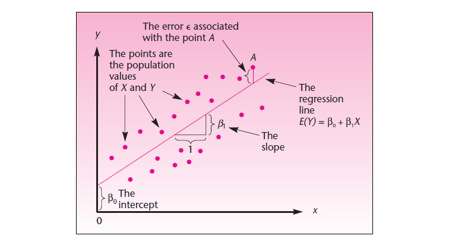

Here is a break down of Simple Linear Regression Model :

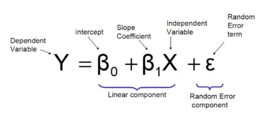

### Assumptions of Simple Linear Regression Model:

1. **Linearity :** The relationship between $X$ and $Y$ is Linear (straight-line) relationship.
1. **Independence of Errors :** Error values are statistically independent i.e., the errors are uncorrelated (not related) with one another in successive observations.
1. **Normality of Error :** The errors $\epsilon$ are normally distributed with mean 0 and a constant variance $\sigma^2$. In symbols, $\epsilon ~ N(0, \sigma^2)$
1. **Equal Variance (Homoscedasticity):** The variance of residual is constant for any value of $X$.

**NOTE :** The simple linear regression model applies only if the true relationship between the two variables $X$ and $Y$ is a straight-line relationship. If the relationship is curved (curvilinear), then we need to use the more involved methods such as Polynomial Regression.

## Parameter Estimation : Search of $\beta_0$ and $ \beta_1$

So far, we have described the population model, that is, the assumed true relationship between the two variables $X$ and $Y$. Our interest is focused on this unknown population relationship, and we want to estimate it, using data. In other words, we estimate the regression model parameters $\beta_0$ and $\beta_1$ from the obtained data.

We denote the estimators by $b_0$ and $b_1$ such as,

The estimated regression equation is given by:

$$ Y = b_0 + b_1 X + e$$

where $b_0$ estimates $\beta_0$, $b_1$ estimates $\beta_1$ and $e$ stands for the observed errors called **residuals** from fitting the straight line $ b_0 + b_1 X$ to the data set of $n$ points.

**NOTE: Even though you see the word error here, it does not refer to the epsilon ($\epsilon$) term from above! The error involved here refer to the residuals!**

In terms of the dataset, above equation can be written with subscript $i$ to signify each particular data point such as:

$$y_i = b_0 + b_1 x_i + e_i$$

where $i = 1, 2,...,n$. Then $e_1$ is the first residual, the distance from the first data point to the fitted regression line; $e_2$ is the distance from the second data point to the line; and so on to en , the $n^{th}$ error. The errors $e_i$ are viewed as estimates of the true population errors $\epsilon_i$. The equation of the regression line itself is as follows:

The regression line : $$\hat Y = b_0 + b_1 X$$

where $\hat Y$ (pronounced “Y-hat”) is the $Y$ value lying on the fitted regression line for a given $X$.

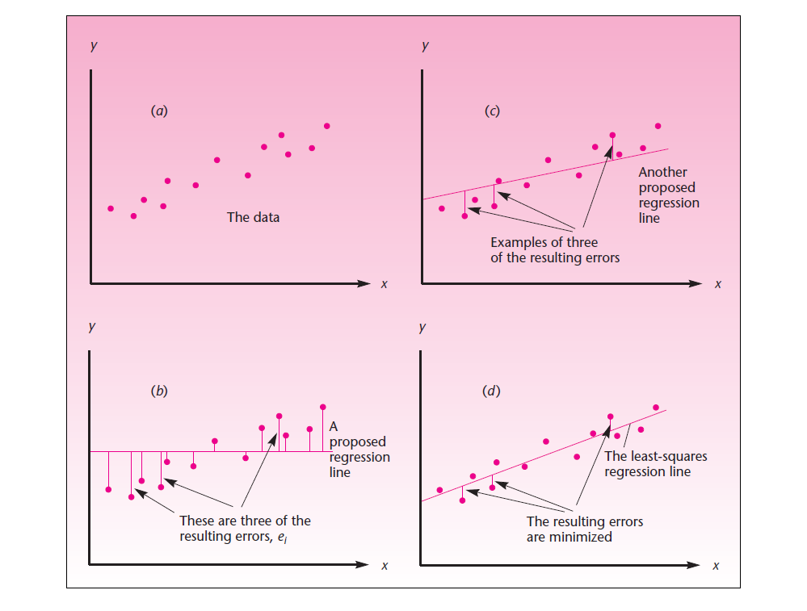

As can be seen from above figure,

- the regression line proposed in part (b) results in very large errors.
- the errors corresponding to the line of part (c) are smaller than the ones of part (b), but the errors resulting from using the line proposed in part (d) are by far the smallest.
- the line in part (d) seems to move with the data and minimize the resulting errors.

[figure not shown]

## Ordinary Least Squares (OLS) estimate:

Linear regression models are not perfect. It tries to approximate the relationship between dependent and independent variables in a straight line. Approximation leads to errors.

Thus, the linear model will not predict all the data accurately, meaning that there is a difference between the actual value and the prediction. The error is easily calculated with:

$$\boxed {\large e_i = y_i - \hat y_i}$$

i.e, **subtract the prediction from the true value**

If we want to minimize all the errors (both positive and negative ones), we should minimize the **Sum of the Squared Errors (SSE)**. Thus, we want to find the least-squares line—the line that minimizes SSE. We define the sum of squares for error in regression as,

$$SSE = \sum_{i=1}^{n}{e_i}^2 = \sum_{i=1}^{n}{(y_i - \hat y_i)^2}$$

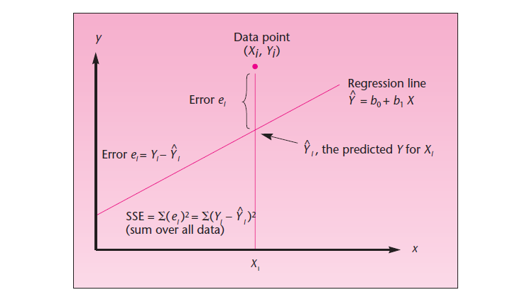

The figure above shows how the errors lead to the calculation of SSE.

Calculus is used in finding the expressions for $b_0$ and $b_1$ that minimize SSE. These expressions are called the normal equations and are given by : $$\sum_{i=1}^{n} y_i = n b_0 + b_1 \sum_{i=1}^{n} x_i $$

$$\sum_{i=1}^{n} x_i y_i = b_0 \sum_{i=1}^{n} x_i + b_1 \sum_{i=1}^{n} {x_i}^2 $$

This system of two equations with two unknowns is solved to give us the values of $b_0$ and $b_1$ that minimize SSE. The results are the **least-squares estimators** $b_0$ and $b_1$ of the Simple Linear Regression parameters $\beta_0$ and $\beta_1$.

After some math that is too heavy for this tutorial, you can finally estimate the coefficients with the following equations:

$$b_1 = \frac{\sum_{i=1}^{n}(x_i-\bar{x})(y_i-\bar{y})}{\sum_{i=1}^{n}(x_i-\bar{x})^2} = \frac{Cov(X,Y)}{Var(X)}$$$$b_0 = \bar y - b_1\bar x$$

Where $\bar x$ and $\bar y$ represent the mean.

### OLS at a glance :

Computing a Least Squares fit is quick, easy and often good enough, so here’s how:

1. Compute the sample means, $\bar x$ and $\bar y$, the variance of $X$, and the covariance of $X$ and $Y$.
1. The estimated slope is $$\hat{\beta_1} = b_1 = \frac{Cov(X,Y)}{Var(X)}$$
2. And the intercept is $$\hat{\beta_0} = b_0 = \bar y - \hat{\beta_1} \bar x$$

- $b_0$ is the estimated average value of $Y$ when the value of $X$ is zero
- $b_1$ is the estimated change in the average value of $Y$ as a result of a one-unit change in $X$

# 8.3. Model Evaluation : How good is the Regression ?

The quality of a regression model is how well its predictions match up against actual values, but how do we actually evaluate quality? Luckily, smart statisticians have developed error metrics to judge the quality of a model. In this section we will see some of the most popular error metrics used in practice.

### Mean Absolute Error (MAE)

The mean absolute error (MAE) is the simplest regression error metric to understand. We’ll calculate the residual for every data point, taking only the absolute value of each so that negative and positive residuals do not cancel out. We then take the average of all these residuals. Effectively, MAE describes the typical magnitude of the residuals.

$$MAE = \large{1 \over n }{\sum_{i}^{n}|y_i - \hat y_i|}$$

A small MAE suggests the model is great at prediction, while a large MAE suggests that your model may have trouble in certain areas. A MAE of 0 means that your model is a perfect predictor of the outputs (but this will almost never happen)

The MAE is also the most intuitive of the metrics since we’re just looking at the absolute difference between the data and the model’s predictions. While the MAE is easily interpretable, using the absolute value of the residual often is not as desirable as squaring this difference.

### Mean Square Error (MSE)

The mean square error (MSE) is just like the MAE, but squares the difference before summing them all instead of using the absolute value. We can see this difference in the equation below.

$$MSE = \large{1 \over n }{\sum_{i}^{n}(y_i - \hat y_i)^2}$$

Because we are squaring the difference, our model will be penalized more for making predictions that differ greatly from the corresponding actual value. This is to say that large differences between actual and predicted are punished more in MSE than in MAE.

### Root Mean Square Error (RMSE)

Another error metric you may encounter is the root mean squared error (RMSE). As the name suggests, it is the square root of the MSE. Because the MSE is squared, its units do not match that of the original output. Researchers will often use RMSE to convert the error metric back into similar units, making interpretation easier. Since the MSE and RMSE both square the residual, they are similarly affected by outliers.

$$\large RMSE = \sqrt {{1 \over n }{\sum_{i}^{n}(y_i - \hat y_i)^2}}$$

### Coefficient of Determination ($\large r^{\;\small 2}$)

The coefficient of determination $\large r^{\;\small 2}$ is a descriptive measure of the strength of the regression relationship, **a measure of how well the regression line fits the data.**

We will now see how the coefficient of determination is obtained directly from a decomposition of the variation in Y into a component due to error and a component due to the regression.

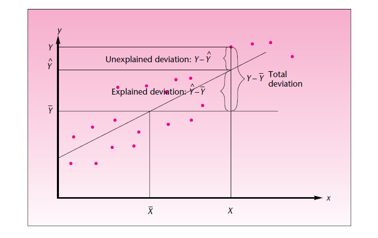

As can be seen from the figure:

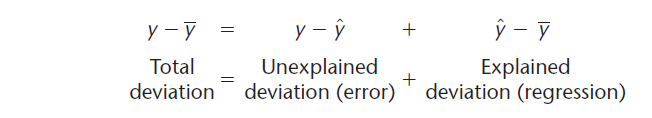

The error is also called the unexplained deviation because it is a deviation that cannot be explained by the regression relationship; the regression deviation is also called the explained deviation because it is that part of the deviation of a data point from the mean that can be explained by the regression relationship between X and Y.

As in the analysis of variance, we square all three deviations for each one of our data points, and we sum over all n points.

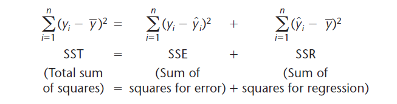

We define the coefficient of determination as the sum of squares due to the regression divided by the total sum of squares. And since, SSE and SSR add to SST, the coefficient of determination is:

$$\large {r^2} = \frac {SSR}{SST} = \large {1} - \frac {SSE}{SST} $$

Thus, The coefficient of determination can be interpreted as the proportion of the variation in $Y$ that is explained by the regression relationship of $Y$ with $X$. Recall that the correlation coefficient $\large r$ can be between $-1$ and $1$. Its square, $r^2$, can therefore be anywhere from $0$ to $1$.

When $r^2 = 1$, we know that 100% of the variation in $Y$ is explained by $X$. This means that the data all lie right on the regression line, and no errors result i.e., SSE must be equal to zero. At the other extreme is the case where the regression line explains nothing. Here the errors account for everything, and SSR is zero. In this case, $r^2 = 0$ and $X$ and $Y$ have no linear relationship.

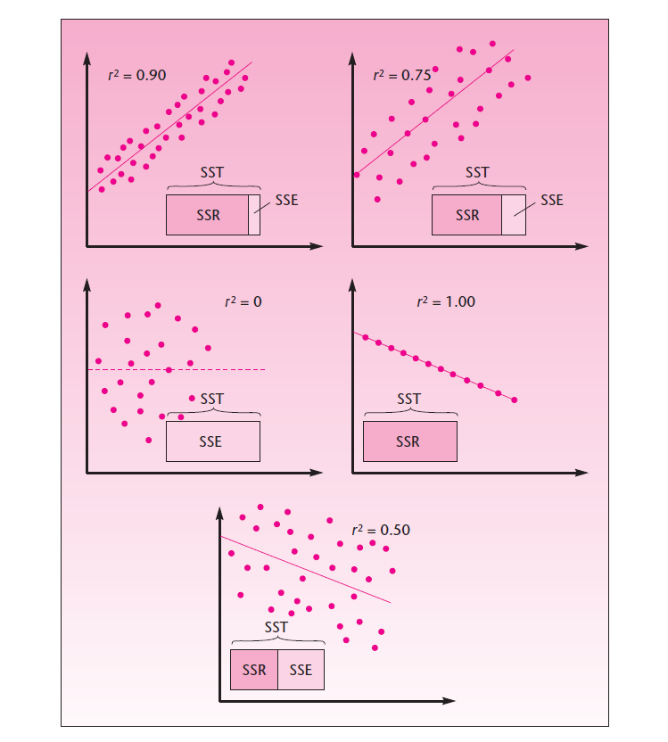

Above figure shows several regressions and their corresponding $r^2$ values. If you think of the total sum of squared deviations as being in a box, then $r^2$ is the proportion of the box that is filled with the explained sum of squares, the remaining part being the squared errors. This is shown for each regression in the figure.

# 8.4. Making Predictions

As mentioned earlier in this section, a regression model has several possible uses. One is to understand the relationship between the two variables. A more frequent use of a regression analysis is prediction: providing estimates of values of the dependent variable by using the prediction equation:

$$\hat Y = b_0 + b_1 X$$

Producing predictions using the estimated regression equation is very easy. All we need to do is to substitute the value of $X$ for which we want to predict $Y$ into the prediction equation along with the estimated value of intercept ($\beta_0$) which is $b_0$ and estimated values of coefficient ($\beta_1$) which is $b_1$ . For example, if a Simple Linear Regression model is fitted over *House Prices in ('1000 \$)* and *House Area (in Sq. feet)* and the intercept $b_0 = 126.0258 $ whereas the coefficient $b_1 = 0.0942$ then according to the prediction equation,

$$\hat Y = 126.0258 + 0.0942 * X$$$$ predicted \; house \; price = 126.0258 + 0.0942 * house \; area $$